# Risk Factor Analysis

## Outcome Variable

**Outcome Variable:** pers_wast

## Predictor Variables

**Intervention Variable:** enstunt

**Adjustment Set:**

- arm
- sex
- W_mage
- meducyrs
- feducyrs
- vagbrth
- single
- brthmon
- W_parity
- delta_W_mage
- delta_meducyrs
- delta_feducyrs
- delta_vagbrth
- delta_single
- delta_brthmon
- delta_W_parity

## Stratifying Variables

The analysis was stratified on these variable(s):

- agecat
- studyid
- country

## Data Summary

| agecat | studyid | country | enstunt | pers_wast | n_cell | n |
| --- | --- | --- | --- | --- | --- | --- |
| 0-24 months | ki0047075b-MAL-ED | BANGLADESH | 0 | 0 | 198 | 248 |
| 0-24 months | ki0047075b-MAL-ED | BANGLADESH | 0 | 1 | 9 | 248 |
| 0-24 months | ki0047075b-MAL-ED | BANGLADESH | 1 | 0 | 37 | 248 |
| 0-24 months | ki0047075b-MAL-ED | BANGLADESH | 1 | 1 | 4 | 248 |
| 0-24 months | ki0047075b-MAL-ED | BRAZIL | 0 | 0 | 190 | 218 |
| 0-24 months | ki0047075b-MAL-ED | BRAZIL | 0 | 1 | 2 | 218 |
| 0-24 months | ki0047075b-MAL-ED | BRAZIL | 1 | 0 | 26 | 218 |
| 0-24 months | ki0047075b-MAL-ED | BRAZIL | 1 | 1 | 0 | 218 |
| 0-24 months | ki0047075b-MAL-ED | INDIA | 0 | 0 | 184 | 241 |
| 0-24 months | ki0047075b-MAL-ED | INDIA | 0 | 1 | 17 | 241 |
| 0-24 months | ki0047075b-MAL-ED | INDIA | 1 | 0 | 36 | 241 |
| 0-24 months | ki0047075b-MAL-ED | INDIA | 1 | 1 | 4 | 241 |
| 0-24 months | ki0047075b-MAL-ED | NEPAL | 0 | 0 | 207 | 238 |
| 0-24 months | ki0047075b-MAL-ED | NEPAL | 0 | 1 | 3 | 238 |
| 0-24 months | ki0047075b-MAL-ED | NEPAL | 1 | 0 | 27 | 238 |
| 0-24 months | ki0047075b-MAL-ED | NEPAL | 1 | 1 | 1 | 238 |
| 0-24 months | ki0047075b-MAL-ED | PERU | 0 | 0 | 247 | 284 |
| 0-24 months | ki0047075b-MAL-ED | PERU | 0 | 1 | 1 | 284 |
| 0-24 months | ki0047075b-MAL-ED | PERU | 1 | 0 | 36 | 284 |
| 0-24 months | ki0047075b-MAL-ED | PERU | 1 | 1 | 0 | 284 |
| 0-24 months | ki0047075b-MAL-ED | SOUTH AFRICA | 0 | 0 | 242 | 275 |
| 0-24 months | ki0047075b-MAL-ED | SOUTH AFRICA | 0 | 1 | 2 | 275 |
| 0-24 months | ki0047075b-MAL-ED | SOUTH AFRICA | 1 | 0 | 31 | 275 |
| 0-24 months | ki0047075b-MAL-ED | SOUTH AFRICA | 1 | 1 | 0 | 275 |
| 0-24 months | ki0047075b-MAL-ED | TANZANIA, UNITED REPUBLIC OF | 0 | 0 | 214 | 253 |
| 0-24 months | ki0047075b-MAL-ED | TANZANIA, UNITED REPUBLIC OF | 0 | 1 | 0 | 253 |
| 0-24 months | ki0047075b-MAL-ED | TANZANIA, UNITED REPUBLIC OF | 1 | 0 | 39 | 253 |
| 0-24 months | ki0047075b-MAL-ED | TANZANIA, UNITED REPUBLIC OF | 1 | 1 | 0 | 253 |
| 0-24 months | ki1000108-CMC-V-BCS-2002 | INDIA | 0 | 0 | 281 | 373 |
| 0-24 months | ki1000108-CMC-V-BCS-2002 | INDIA | 0 | 1 | 15 | 373 |

[output cut: 310 more lines]

The following strata were considered:

- agecat: 0-24 months, studyid: ki0047075b-MAL-ED, country: BANGLADESH
- agecat: 0-24 months, studyid: ki0047075b-MAL-ED, country: BRAZIL
- agecat: 0-24 months, studyid: ki0047075b-MAL-ED, country: INDIA
- agecat: 0-24 months, studyid: ki0047075b-MAL-ED, country: NEPAL
- agecat: 0-24 months, studyid: ki0047075b-MAL-ED, country: PERU
- agecat: 0-24 months, studyid: ki0047075b-MAL-ED, country: SOUTH AFRICA
- agecat: 0-24 months, studyid: ki0047075b-MAL-ED, country: TANZANIA, UNITED REPUBLIC OF
- agecat: 0-24 months, studyid: ki1000108-CMC-V-BCS-2002, country: INDIA
- agecat: 0-24 months, studyid: ki1000108-IRC, country: INDIA
- agecat: 0-24 months, studyid: ki1000109-EE, country: PAKISTAN
- agecat: 0-24 months, studyid: ki1000109-ResPak, country: PAKISTAN
- agecat: 0-24 months, studyid: ki1000304b-SAS-CompFeed, country: INDIA
- agecat: 0-24 months, studyid: ki1000304b-SAS-FoodSuppl, country: INDIA
- agecat: 0-24 months, studyid: ki1017093-NIH-Birth, country: BANGLADESH
- agecat: 0-24 months, studyid: ki1017093b-PROVIDE, country: BANGLADESH
- agecat: 0-24 months, studyid: ki1017093c-NIH-Crypto, country: BANGLADESH
- agecat: 0-24 months, studyid: ki1066203-TanzaniaChild2, country: TANZANIA, UNITED REPUBLIC OF
- agecat: 0-24 months, studyid: ki1101329-Keneba, country: GAMBIA
- agecat: 0-24 months, studyid: ki1112895-Guatemala BSC, country: GUATEMALA
- agecat: 0-24 months, studyid: ki1112895-iLiNS-Zinc, country: BURKINA FASO
- agecat: 0-24 months, studyid: ki1113344-GMS-Nepal, country: NEPAL
- agecat: 0-24 months, studyid: ki1114097-CMIN, country: BANGLADESH
- agecat: 0-24 months, studyid: ki1114097-CONTENT, country: PERU
- agecat: 0-24 months, studyid: ki1119695-PROBIT, country: BELARUS
- agecat: 0-24 months, studyid: ki1126311-ZVITAMBO, country: ZIMBABWE
- agecat: 0-24 months, studyid: ki1135781-COHORTS, country: GUATEMALA
- agecat: 0-24 months, studyid: ki1135781-COHORTS, country: INDIA
- agecat: 0-24 months, studyid: ki1135781-COHORTS, country: PHILIPPINES
- agecat: 0-24 months, studyid: ki1148112-LCNI-5, country: MALAWI
- agecat: 0-24 months, studyid: kiGH5241-JiVitA-3, country: BANGLADESH
- agecat: 0-24 months, studyid: kiGH5241-JiVitA-4, country: BANGLADESH
- agecat: 0-6 months, studyid: ki0047075b-MAL-ED, country: BANGLADESH
- agecat: 0-6 months, studyid: ki0047075b-MAL-ED, country: BRAZIL
- agecat: 0-6 months, studyid: ki0047075b-MAL-ED, country: INDIA
- agecat: 0-6 months, studyid: ki0047075b-MAL-ED, country: NEPAL
- agecat: 0-6 months, studyid: ki0047075b-MAL-ED, country: PERU
- agecat: 0-6 months, studyid: ki0047075b-MAL-ED, country: SOUTH AFRICA
- agecat: 0-6 months, studyid: ki0047075b-MAL-ED, country: TANZANIA, UNITED REPUBLIC OF
- agecat: 0-6 months, studyid: ki1000108-CMC-V-BCS-2002, country: INDIA
- agecat: 0-6 months, studyid: ki1000108-IRC, country: INDIA
- agecat: 0-6 months, studyid: ki1000109-EE, country: PAKISTAN
- agecat: 0-6 months, studyid: ki1000109-ResPak, country: PAKISTAN
- agecat: 0-6 months, studyid: ki1017093-NIH-Birth, country: BANGLADESH
- agecat: 0-6 months, studyid: ki1017093b-PROVIDE, country: BANGLADESH
- agecat: 0-6 months, studyid: ki1017093c-NIH-Crypto, country: BANGLADESH
- agecat: 0-6 months, studyid: ki1066203-TanzaniaChild2, country: TANZANIA, UNITED REPUBLIC OF
- agecat: 0-6 months, studyid: ki1101329-Keneba, country: GAMBIA
- agecat: 0-6 months, studyid: ki1113344-GMS-Nepal, country: NEPAL
- agecat: 0-6 months, studyid: ki1114097-CMIN, country: BANGLADESH
- agecat: 0-6 months, studyid: ki1114097-CONTENT, country: PERU
- agecat: 0-6 months, studyid: ki1119695-PROBIT, country: BELARUS
- agecat: 0-6 months, studyid: ki1126311-ZVITAMBO, country: ZIMBABWE
- agecat: 0-6 months, studyid: ki1135781-COHORTS, country: PHILIPPINES
- agecat: 0-6 months, studyid: kiGH5241-JiVitA-3, country: BANGLADESH
- agecat: 6-24 months, studyid: ki0047075b-MAL-ED, country: BANGLADESH
- agecat: 6-24 months, studyid: ki0047075b-MAL-ED, country: BRAZIL
- agecat: 6-24 months, studyid: ki0047075b-MAL-ED, country: INDIA
- agecat: 6-24 months, studyid: ki0047075b-MAL-ED, country: NEPAL
- agecat: 6-24 months, studyid: ki0047075b-MAL-ED, country: PERU
- agecat: 6-24 months, studyid: ki0047075b-MAL-ED, country: SOUTH AFRICA
- agecat: 6-24 months, studyid: ki0047075b-MAL-ED, country: TANZANIA, UNITED REPUBLIC OF
- agecat: 6-24 months, studyid: ki1000108-CMC-V-BCS-2002, country: INDIA
- agecat: 6-24 months, studyid: ki1000108-IRC, country: INDIA
- agecat: 6-24 months, studyid: ki1000109-EE, country: PAKISTAN
- agecat: 6-24 months, studyid: ki1000109-ResPak, country: PAKISTAN
- agecat: 6-24 months, studyid: ki1000304b-SAS-CompFeed, country: INDIA
- agecat: 6-24 months, studyid: ki1000304b-SAS-FoodSuppl, country: INDIA
- agecat: 6-24 months, studyid: ki1017093-NIH-Birth, country: BANGLADESH
- agecat: 6-24 months, studyid: ki1017093b-PROVIDE, country: BANGLADESH
- agecat: 6-24 months, studyid: ki1017093c-NIH-Crypto, country: BANGLADESH
- agecat: 6-24 months, studyid: ki1066203-TanzaniaChild2, country: TANZANIA, UNITED REPUBLIC OF
- agecat: 6-24 months, studyid: ki1101329-Keneba, country: GAMBIA
- agecat: 6-24 months, studyid: ki1112895-Guatemala BSC, country: GUATEMALA
- agecat: 6-24 months, studyid: ki1112895-iLiNS-Zinc, country: BURKINA FASO
- agecat: 6-24 months, studyid: ki1113344-GMS-Nepal, country: NEPAL
- agecat: 6-24 months, studyid: ki1114097-CMIN, country: BANGLADESH
- agecat: 6-24 months, studyid: ki1114097-CONTENT, country: PERU
- agecat: 6-24 months, studyid: ki1119695-PROBIT, country: BELARUS
- agecat: 6-24 months, studyid: ki1126311-ZVITAMBO, country: ZIMBABWE
- agecat: 6-24 months, studyid: ki1135781-COHORTS, country: GUATEMALA
- agecat: 6-24 months, studyid: ki1135781-COHORTS, country: INDIA
- agecat: 6-24 months, studyid: ki1135781-COHORTS, country: PHILIPPINES
- agecat: 6-24 months, studyid: ki1148112-LCNI-5, country: MALAWI
- agecat: 6-24 months, studyid: kiGH5241-JiVitA-3, country: BANGLADESH
- agecat: 6-24 months, studyid: kiGH5241-JiVitA-4, country: BANGLADESH

### Dropped Strata

Some strata were dropped due to rare outcomes:

- agecat: 0-24 months, studyid: ki0047075b-MAL-ED, country: BANGLADESH
- agecat: 0-24 months, studyid: ki0047075b-MAL-ED, country: BRAZIL
- agecat: 0-24 months, studyid: ki0047075b-MAL-ED, country: INDIA
- agecat: 0-24 months, studyid: ki0047075b-MAL-ED, country: NEPAL
- agecat: 0-24 months, studyid: ki0047075b-MAL-ED, country: PERU
- agecat: 0-24 months, studyid: ki0047075b-MAL-ED, country: SOUTH AFRICA
- agecat: 0-24 months, studyid: ki0047075b-MAL-ED, country: TANZANIA, UNITED REPUBLIC OF
- agecat: 0-24 months, studyid: ki1017093b-PROVIDE, country: BANGLADESH
- agecat: 0-24 months, studyid: ki1066203-TanzaniaChild2, country: TANZANIA, UNITED REPUBLIC OF
- agecat: 0-24 months, studyid: ki1112895-Guatemala BSC, country: GUATEMALA
- agecat: 0-24 months, studyid: ki1114097-CONTENT, country: PERU
- agecat: 0-24 months, studyid: ki1119695-PROBIT, country: BELARUS
- agecat: 0-24 months, studyid: ki1148112-LCNI-5, country: MALAWI
- agecat: 0-6 months, studyid: ki0047075b-MAL-ED, country: BANGLADESH
- agecat: 0-6 months, studyid: ki0047075b-MAL-ED, country: BRAZIL
- agecat: 0-6 months, studyid: ki0047075b-MAL-ED, country: INDIA
- agecat: 0-6 months, studyid: ki0047075b-MAL-ED, country: NEPAL
- agecat: 0-6 months, studyid: ki0047075b-MAL-ED, country: PERU
- agecat: 0-6 months, studyid: ki0047075b-MAL-ED, country: SOUTH AFRICA
- agecat: 0-6 months, studyid: ki0047075b-MAL-ED, country: TANZANIA, UNITED REPUBLIC OF
- agecat: 0-6 months, studyid: ki1017093-NIH-Birth, country: BANGLADESH
- agecat: 0-6 months, studyid: ki1017093b-PROVIDE, country: BANGLADESH
- agecat: 0-6 months, studyid: ki1017093c-NIH-Crypto, country: BANGLADESH
- agecat: 0-6 months, studyid: ki1066203-TanzaniaChild2, country: TANZANIA, UNITED REPUBLIC OF
- agecat: 0-6 months, studyid: ki1114097-CMIN, country: BANGLADESH
- agecat: 0-6 months, studyid: ki1114097-CONTENT, country: PERU
- agecat: 0-6 months, studyid: ki1119695-PROBIT, country: BELARUS
- agecat: 0-6 months, studyid: ki1126311-ZVITAMBO, country: ZIMBABWE
- agecat: 0-6 months, studyid: ki1135781-COHORTS, country: PHILIPPINES
- agecat: 0-6 months, studyid: kiGH5241-JiVitA-3, country: BANGLADESH
- agecat: 6-24 months, studyid: ki0047075b-MAL-ED, country: BANGLADESH
- agecat: 6-24 months, studyid: ki0047075b-MAL-ED, country: BRAZIL
- agecat: 6-24 months, studyid: ki0047075b-MAL-ED, country: INDIA
- agecat: 6-24 months, studyid: ki0047075b-MAL-ED, country: NEPAL
- agecat: 6-24 months, studyid: ki0047075b-MAL-ED, country: PERU
- agecat: 6-24 months, studyid: ki0047075b-MAL-ED, country: SOUTH AFRICA
- agecat: 6-24 months, studyid: ki0047075b-MAL-ED, country: TANZANIA, UNITED REPUBLIC OF
- agecat: 6-24 months, studyid: ki1017093b-PROVIDE, country: BANGLADESH
- agecat: 6-24 months, studyid: ki1066203-TanzaniaChild2, country: TANZANIA, UNITED REPUBLIC OF
- agecat: 6-24 months, studyid: ki1112895-Guatemala BSC, country: GUATEMALA
- agecat: 6-24 months, studyid: ki1114097-CONTENT, country: PERU
- agecat: 6-24 months, studyid: ki1119695-PROBIT, country: BELARUS
- agecat: 6-24 months, studyid: ki1148112-LCNI-5, country: MALAWI

## Methods Detail

We’re interested in the causal parameters $E[Y_a]$ for all values of $a \in \mathcal{A}$. These parameters represent the mean outcome if, possibly contrary to fact, we intervened to set all units to have $A=a$. Under the randomization and positivity assumptions, these are identified by the statistical parameters $\psi_a=E_W[E_{Y|A,W}(Y|A=a,W)]$. In addition, we’re interested in the mean of $Y$, $E[Y]$ under no intervention (the observed mean). We will estimate these parameters by using SuperLearner to fit the relevant likelihood factors – $E_{Y|A,W}(Y|A=a,W)$ and $p(A=a|W)$, and then updating our likelihood fit using a joint TMLE.

For unadjusted analyses ($W=\{\}$), initial likelihoods were estimated using Lrnr_glm to estimate the simple $E(Y|A)$ and Lrnr_mean to estimate $p(A)$. For adjusted analyses, a small library containing Lrnr_glmnet, Lrnr_xgboost, and Lrnr_mean was used.

Having estimated these parameters, we will then use the delta method to estimate relative risks and attributable risks relative to a prespecified baseline level of $A$.

# Results Detail

## Results Plots

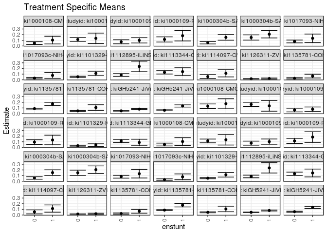

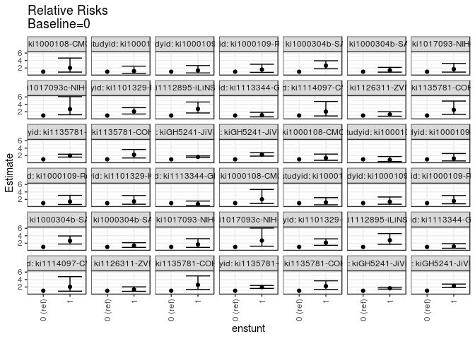

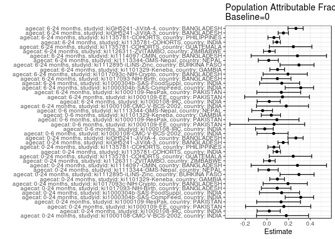

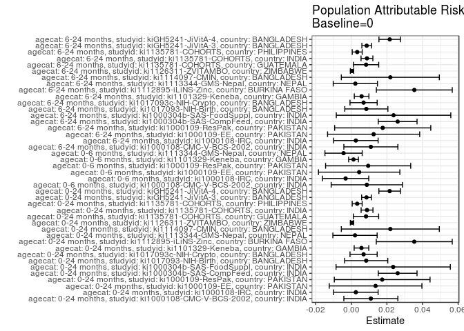

## Results Table

### Parameter: TSM

| agecat | studyid | country | intervention_level | baseline_level | estimate | ci_lower | ci_upper |
| --- | --- | --- | --- | --- | --- | --- | --- |
| 0-24 months | ki1000108-CMC-V-BCS-2002 | INDIA | 0 | NA | 0.0506757 | 0.0256554 | 0.0756960 |
| 0-24 months | ki1000108-CMC-V-BCS-2002 | INDIA | 1 | NA | 0.1038961 | 0.0356521 | 0.1721401 |
| 0-24 months | ki1000108-IRC | INDIA | 0 | NA | 0.1145251 | 0.0814977 | 0.1475526 |
| 0-24 months | ki1000108-IRC | INDIA | 1 | NA | 0.1346154 | 0.0417340 | 0.2274968 |
| 0-24 months | ki1000109-EE | PAKISTAN | 0 | NA | 0.0738930 | 0.0379329 | 0.1098531 |
| 0-24 months | ki1000109-EE | PAKISTAN | 1 | NA | 0.0991992 | 0.0525401 | 0.1458583 |
| 0-24 months | ki1000109-ResPak | PAKISTAN | 0 | NA | 0.1154658 | 0.0696561 | 0.1612754 |
| 0-24 months | ki1000109-ResPak | PAKISTAN | 1 | NA | 0.1817722 | 0.0884502 | 0.2750942 |
| 0-24 months | ki1000304b-SAS-CompFeed | INDIA | 0 | NA | 0.0574179 | 0.0352700 | 0.0795657 |
| 0-24 months | ki1000304b-SAS-CompFeed | INDIA | 1 | NA | 0.1519030 | 0.1020087 | 0.2017974 |
| 0-24 months | ki1000304b-SAS-FoodSuppl | INDIA | 0 | NA | 0.1498058 | 0.1032705 | 0.1963411 |
| 0-24 months | ki1000304b-SAS-FoodSuppl | INDIA | 1 | NA | 0.2077728 | 0.1420532 | 0.2734924 |
| 0-24 months | ki1017093-NIH-Birth | BANGLADESH | 0 | NA | 0.0796363 | 0.0546439 | 0.1046287 |
| 0-24 months | ki1017093-NIH-Birth | BANGLADESH | 1 | NA | 0.1352207 | 0.0592180 | 0.2112234 |
| 0-24 months | ki1017093c-NIH-Crypto | BANGLADESH | 0 | NA | 0.0287081 | 0.0156287 | 0.0417876 |
| 0-24 months | ki1017093c-NIH-Crypto | BANGLADESH | 1 | NA | 0.0776699 | 0.0259454 | 0.1293945 |
| 0-24 months | ki1101329-Keneba | GAMBIA | 0 | NA | 0.0536127 | 0.0441833 | 0.0630421 |
| 0-24 months | ki1101329-Keneba | GAMBIA | 1 | NA | 0.1120681 | 0.0721568 | 0.1519794 |
| 0-24 months | ki1112895-iLiNS-Zinc | BURKINA FASO | 0 | NA | 0.0844653 | 0.0609681 | 0.1079624 |
| 0-24 months | ki1112895-iLiNS-Zinc | BURKINA FASO | 1 | NA | 0.2357546 | 0.1425269 | 0.3289823 |
| 0-24 months | ki1113344-GMS-Nepal | NEPAL | 0 | NA | 0.1319152 | 0.1021895 | 0.1616409 |
| 0-24 months | ki1113344-GMS-Nepal | NEPAL | 1 | NA | 0.1436967 | 0.0744319 | 0.2129614 |
| 0-24 months | ki1114097-CMIN | BANGLADESH | 0 | NA | 0.0559006 | 0.0203458 | 0.0914555 |
| 0-24 months | ki1114097-CMIN | BANGLADESH | 1 | NA | 0.1145833 | 0.0507432 | 0.1784234 |
| 0-24 months | ki1126311-ZVITAMBO | ZIMBABWE | 0 | NA | 0.0172164 | 0.0144675 | 0.0199653 |
| 0-24 months | ki1126311-ZVITAMBO | ZIMBABWE | 1 | NA | 0.0219446 | 0.0125934 | 0.0312959 |
| 0-24 months | ki1135781-COHORTS | GUATEMALA | 0 | NA | 0.0258224 | 0.0151598 | 0.0364850 |
| 0-24 months | ki1135781-COHORTS | GUATEMALA | 1 | NA | 0.0652213 | 0.0317128 | 0.0987298 |
| 0-24 months | ki1135781-COHORTS | INDIA | 0 | NA | 0.0875654 | 0.0798195 | 0.0953113 |
| 0-24 months | ki1135781-COHORTS | INDIA | 1 | NA | 0.1703979 | 0.1400789 | 0.2007169 |

[output cut: 54 more lines]

### Parameter: E(Y)

| agecat | studyid | country | intervention_level | baseline_level | estimate | ci_lower | ci_upper |
| --- | --- | --- | --- | --- | --- | --- | --- |
| 0-24 months | ki1000108-CMC-V-BCS-2002 | INDIA | NA | NA | 0.0616622 | 0.0372186 | 0.0861058 |
| 0-24 months | ki1000108-IRC | INDIA | NA | NA | 0.1170732 | 0.0859146 | 0.1482317 |
| 0-24 months | ki1000109-EE | PAKISTAN | NA | NA | 0.0875332 | 0.0589672 | 0.1160991 |
| 0-24 months | ki1000109-ResPak | PAKISTAN | NA | NA | 0.1328125 | 0.0911588 | 0.1744662 |
| 0-24 months | ki1000304b-SAS-CompFeed | INDIA | NA | NA | 0.0834553 | 0.0601989 | 0.1067118 |
| 0-24 months | ki1000304b-SAS-FoodSuppl | INDIA | NA | NA | 0.1733333 | 0.1349698 | 0.2116969 |
| 0-24 months | ki1017093-NIH-Birth | BANGLADESH | NA | NA | 0.0880150 | 0.0639627 | 0.1120673 |
| 0-24 months | ki1017093c-NIH-Crypto | BANGLADESH | NA | NA | 0.0356164 | 0.0221630 | 0.0490699 |
| 0-24 months | ki1101329-Keneba | GAMBIA | NA | NA | 0.0593290 | 0.0499611 | 0.0686968 |
| 0-24 months | ki1112895-iLiNS-Zinc | BURKINA FASO | NA | NA | 0.1198322 | 0.0943748 | 0.1452897 |
| 0-24 months | ki1113344-GMS-Nepal | NEPAL | NA | NA | 0.1340034 | 0.1066544 | 0.1613523 |
| 0-24 months | ki1114097-CMIN | BANGLADESH | NA | NA | 0.0778210 | 0.0450051 | 0.1106369 |
| 0-24 months | ki1126311-ZVITAMBO | ZIMBABWE | NA | NA | 0.0176341 | 0.0149910 | 0.0202771 |
| 0-24 months | ki1135781-COHORTS | GUATEMALA | NA | NA | 0.0340909 | 0.0231410 | 0.0450408 |
| 0-24 months | ki1135781-COHORTS | INDIA | NA | NA | 0.0964067 | 0.0887472 | 0.1040661 |
| 0-24 months | ki1135781-COHORTS | PHILIPPINES | NA | NA | 0.0512273 | 0.0430760 | 0.0593786 |
| 0-24 months | kiGH5241-JiVitA-3 | BANGLADESH | NA | NA | 0.0568247 | 0.0527145 | 0.0609348 |
| 0-24 months | kiGH5241-JiVitA-4 | BANGLADESH | NA | NA | 0.0806665 | 0.0720540 | 0.0892791 |
| 0-6 months | ki1000108-CMC-V-BCS-2002 | INDIA | NA | NA | 0.1396648 | 0.1037072 | 0.1756225 |
| 0-6 months | ki1000108-IRC | INDIA | NA | NA | 0.1592040 | 0.1233945 | 0.1950135 |
| 0-6 months | ki1000109-EE | PAKISTAN | NA | NA | 0.0673854 | 0.0418419 | 0.0929290 |
| 0-6 months | ki1000109-ResPak | PAKISTAN | NA | NA | 0.1028807 | 0.0646041 | 0.1411572 |
| 0-6 months | ki1101329-Keneba | GAMBIA | NA | NA | 0.0308068 | 0.0233159 | 0.0382978 |
| 0-6 months | ki1113344-GMS-Nepal | NEPAL | NA | NA | 0.1093474 | 0.0836377 | 0.1350572 |
| 6-24 months | ki1000108-CMC-V-BCS-2002 | INDIA | NA | NA | 0.0616622 | 0.0372186 | 0.0861058 |
| 6-24 months | ki1000108-IRC | INDIA | NA | NA | 0.1170732 | 0.0859146 | 0.1482317 |
| 6-24 months | ki1000109-EE | PAKISTAN | NA | NA | 0.0875332 | 0.0589672 | 0.1160991 |
| 6-24 months | ki1000109-ResPak | PAKISTAN | NA | NA | 0.1328125 | 0.0911588 | 0.1744662 |
| 6-24 months | ki1000304b-SAS-CompFeed | INDIA | NA | NA | 0.0834553 | 0.0601989 | 0.1067118 |
| 6-24 months | ki1000304b-SAS-FoodSuppl | INDIA | NA | NA | 0.1733333 | 0.1349698 | 0.2116969 |
| 6-24 months | ki1017093-NIH-Birth | BANGLADESH | NA | NA | 0.0880150 | 0.0639627 | 0.1120673 |
| 6-24 months | ki1017093c-NIH-Crypto | BANGLADESH | NA | NA | 0.0356164 | 0.0221630 | 0.0490699 |
| 6-24 months | ki1101329-Keneba | GAMBIA | NA | NA | 0.0593290 | 0.0499611 | 0.0686968 |
| 6-24 months | ki1112895-iLiNS-Zinc | BURKINA FASO | NA | NA | 0.1198322 | 0.0943748 | 0.1452897 |
| 6-24 months | ki1113344-GMS-Nepal | NEPAL | NA | NA | 0.1340034 | 0.1066544 | 0.1613523 |
| 6-24 months | ki1114097-CMIN | BANGLADESH | NA | NA | 0.0778210 | 0.0450051 | 0.1106369 |
| 6-24 months | ki1126311-ZVITAMBO | ZIMBABWE | NA | NA | 0.0176341 | 0.0149910 | 0.0202771 |
| 6-24 months | ki1135781-COHORTS | GUATEMALA | NA | NA | 0.0340909 | 0.0231410 | 0.0450408 |
| 6-24 months | ki1135781-COHORTS | INDIA | NA | NA | 0.0964067 | 0.0887472 | 0.1040661 |
| 6-24 months | ki1135781-COHORTS | PHILIPPINES | NA | NA | 0.0512273 | 0.0430760 | 0.0593786 |
| 6-24 months | kiGH5241-JiVitA-3 | BANGLADESH | NA | NA | 0.0568247 | 0.0527145 | 0.0609348 |
| 6-24 months | kiGH5241-JiVitA-4 | BANGLADESH | NA | NA | 0.0806665 | 0.0720540 | 0.0892791 |

### Parameter: RR

| agecat | studyid | country | intervention_level | baseline_level | estimate | ci_lower | ci_upper |
| --- | --- | --- | --- | --- | --- | --- | --- |
| 0-24 months | ki1000108-CMC-V-BCS-2002 | INDIA | 0 | 0 | 1.0000000 | 1.0000000 | 1.000000 |
| 0-24 months | ki1000108-CMC-V-BCS-2002 | INDIA | 1 | 0 | 2.0502164 | 0.9014289 | 4.663027 |
| 0-24 months | ki1000108-IRC | INDIA | 0 | 0 | 1.0000000 | 1.0000000 | 1.000000 |
| 0-24 months | ki1000108-IRC | INDIA | 1 | 0 | 1.1754221 | 0.5564423 | 2.482948 |
| 0-24 months | ki1000109-EE | PAKISTAN | 0 | 0 | 1.0000000 | 1.0000000 | 1.000000 |
| 0-24 months | ki1000109-EE | PAKISTAN | 1 | 0 | 1.3424711 | 0.6810079 | 2.646414 |
| 0-24 months | ki1000109-ResPak | PAKISTAN | 0 | 0 | 1.0000000 | 1.0000000 | 1.000000 |
| 0-24 months | ki1000109-ResPak | PAKISTAN | 1 | 0 | 1.5742520 | 0.8261789 | 2.999677 |
| 0-24 months | ki1000304b-SAS-CompFeed | INDIA | 0 | 0 | 1.0000000 | 1.0000000 | 1.000000 |
| 0-24 months | ki1000304b-SAS-CompFeed | INDIA | 1 | 0 | 2.6455711 | 1.7756768 | 3.941622 |
| 0-24 months | ki1000304b-SAS-FoodSuppl | INDIA | 0 | 0 | 1.0000000 | 1.0000000 | 1.000000 |
| 0-24 months | ki1000304b-SAS-FoodSuppl | INDIA | 1 | 0 | 1.3869478 | 0.8892151 | 2.163283 |
| 0-24 months | ki1017093-NIH-Birth | BANGLADESH | 0 | 0 | 1.0000000 | 1.0000000 | 1.000000 |
| 0-24 months | ki1017093-NIH-Birth | BANGLADESH | 1 | 0 | 1.6979772 | 0.8915023 | 3.234009 |
| 0-24 months | ki1017093c-NIH-Crypto | BANGLADESH | 0 | 0 | 1.0000000 | 1.0000000 | 1.000000 |
| 0-24 months | ki1017093c-NIH-Crypto | BANGLADESH | 1 | 0 | 2.7055016 | 1.2073171 | 6.062814 |
| 0-24 months | ki1101329-Keneba | GAMBIA | 0 | 0 | 1.0000000 | 1.0000000 | 1.000000 |
| 0-24 months | ki1101329-Keneba | GAMBIA | 1 | 0 | 2.0903268 | 1.4051899 | 3.109520 |
| 0-24 months | ki1112895-iLiNS-Zinc | BURKINA FASO | 0 | 0 | 1.0000000 | 1.0000000 | 1.000000 |
| 0-24 months | ki1112895-iLiNS-Zinc | BURKINA FASO | 1 | 0 | 2.7911426 | 1.6840977 | 4.625906 |
| 0-24 months | ki1113344-GMS-Nepal | NEPAL | 0 | 0 | 1.0000000 | 1.0000000 | 1.000000 |
| 0-24 months | ki1113344-GMS-Nepal | NEPAL | 1 | 0 | 1.0893104 | 0.6393506 | 1.855941 |
| 0-24 months | ki1114097-CMIN | BANGLADESH | 0 | 0 | 1.0000000 | 1.0000000 | 1.000000 |
| 0-24 months | ki1114097-CMIN | BANGLADESH | 1 | 0 | 2.0497685 | 0.8800068 | 4.774453 |
| 0-24 months | ki1126311-ZVITAMBO | ZIMBABWE | 0 | 0 | 1.0000000 | 1.0000000 | 1.000000 |
| 0-24 months | ki1126311-ZVITAMBO | ZIMBABWE | 1 | 0 | 1.2746322 | 0.8086406 | 2.009159 |
| 0-24 months | ki1135781-COHORTS | GUATEMALA | 0 | 0 | 1.0000000 | 1.0000000 | 1.000000 |
| 0-24 months | ki1135781-COHORTS | GUATEMALA | 1 | 0 | 2.5257684 | 1.3060435 | 4.884605 |
| 0-24 months | ki1135781-COHORTS | INDIA | 0 | 0 | 1.0000000 | 1.0000000 | 1.000000 |
| 0-24 months | ki1135781-COHORTS | INDIA | 1 | 0 | 1.9459505 | 1.5955614 | 2.373286 |

[output cut: 54 more lines]

### Parameter: PAR

| agecat | studyid | country | intervention_level | baseline_level | estimate | ci_lower | ci_upper |
| --- | --- | --- | --- | --- | --- | --- | --- |
| 0-24 months | ki1000108-CMC-V-BCS-2002 | INDIA | 0 | NA | 0.0109865 | -0.0041772 | 0.0261502 |
| 0-24 months | ki1000108-IRC | INDIA | 0 | NA | 0.0025480 | -0.0099714 | 0.0150675 |
| 0-24 months | ki1000109-EE | PAKISTAN | 0 | NA | 0.0136402 | -0.0123876 | 0.0396679 |
| 0-24 months | ki1000109-ResPak | PAKISTAN | 0 | NA | 0.0173467 | -0.0095463 | 0.0442398 |
| 0-24 months | ki1000304b-SAS-CompFeed | INDIA | 0 | NA | 0.0260375 | 0.0151523 | 0.0369226 |
| 0-24 months | ki1000304b-SAS-FoodSuppl | INDIA | 0 | NA | 0.0235276 | -0.0085622 | 0.0556173 |
| 0-24 months | ki1017093-NIH-Birth | BANGLADESH | 0 | NA | 0.0083786 | -0.0037402 | 0.0204975 |
| 0-24 months | ki1017093c-NIH-Crypto | BANGLADESH | 0 | NA | 0.0069083 | -0.0007205 | 0.0145371 |
| 0-24 months | ki1101329-Keneba | GAMBIA | 0 | NA | 0.0057163 | 0.0016175 | 0.0098151 |
| 0-24 months | ki1112895-iLiNS-Zinc | BURKINA FASO | 0 | NA | 0.0353670 | 0.0140304 | 0.0567035 |
| 0-24 months | ki1113344-GMS-Nepal | NEPAL | 0 | NA | 0.0020881 | -0.0103497 | 0.0145259 |
| 0-24 months | ki1114097-CMIN | BANGLADESH | 0 | NA | 0.0219204 | -0.0055961 | 0.0494369 |
| 0-24 months | ki1126311-ZVITAMBO | ZIMBABWE | 0 | NA | 0.0004177 | -0.0005312 | 0.0013665 |
| 0-24 months | ki1135781-COHORTS | GUATEMALA | 0 | NA | 0.0082685 | 0.0011653 | 0.0153718 |
| 0-24 months | ki1135781-COHORTS | INDIA | 0 | NA | 0.0088413 | 0.0055161 | 0.0121665 |
| 0-24 months | ki1135781-COHORTS | PHILIPPINES | 0 | NA | 0.0033079 | 0.0005015 | 0.0061144 |
| 0-24 months | kiGH5241-JiVitA-3 | BANGLADESH | 0 | NA | 0.0085384 | 0.0058126 | 0.0112643 |
| 0-24 months | kiGH5241-JiVitA-4 | BANGLADESH | 0 | NA | 0.0215502 | 0.0154962 | 0.0276043 |
| 0-6 months | ki1000108-CMC-V-BCS-2002 | INDIA | 0 | NA | 0.0087285 | -0.0112950 | 0.0287519 |
| 0-6 months | ki1000108-IRC | INDIA | 0 | NA | -0.0031892 | -0.0161740 | 0.0097956 |
| 0-6 months | ki1000109-EE | PAKISTAN | 0 | NA | 0.0044169 | -0.0184368 | 0.0272706 |
| 0-6 months | ki1000109-ResPak | PAKISTAN | 0 | NA | 0.0094741 | -0.0144300 | 0.0333782 |
| 0-6 months | ki1101329-Keneba | GAMBIA | 0 | NA | 0.0012528 | -0.0014934 | 0.0039991 |
| 0-6 months | ki1113344-GMS-Nepal | NEPAL | 0 | NA | -0.0043368 | -0.0148050 | 0.0061315 |
| 6-24 months | ki1000108-CMC-V-BCS-2002 | INDIA | 0 | NA | 0.0109865 | -0.0041772 | 0.0261502 |
| 6-24 months | ki1000108-IRC | INDIA | 0 | NA | 0.0025480 | -0.0099714 | 0.0150675 |
| 6-24 months | ki1000109-EE | PAKISTAN | 0 | NA | 0.0125513 | -0.0133199 | 0.0384226 |
| 6-24 months | ki1000109-ResPak | PAKISTAN | 0 | NA | 0.0176499 | -0.0093446 | 0.0446444 |
| 6-24 months | ki1000304b-SAS-CompFeed | INDIA | 0 | NA | 0.0260375 | 0.0151523 | 0.0369226 |
| 6-24 months | ki1000304b-SAS-FoodSuppl | INDIA | 0 | NA | 0.0237369 | -0.0084179 | 0.0558918 |
| 6-24 months | ki1017093-NIH-Birth | BANGLADESH | 0 | NA | 0.0084538 | -0.0036516 | 0.0205592 |
| 6-24 months | ki1017093c-NIH-Crypto | BANGLADESH | 0 | NA | 0.0069083 | -0.0007205 | 0.0145371 |
| 6-24 months | ki1101329-Keneba | GAMBIA | 0 | NA | 0.0057922 | 0.0016846 | 0.0098998 |
| 6-24 months | ki1112895-iLiNS-Zinc | BURKINA FASO | 0 | NA | 0.0353937 | 0.0140787 | 0.0567087 |
| 6-24 months | ki1113344-GMS-Nepal | NEPAL | 0 | NA | 0.0022730 | -0.0101510 | 0.0146969 |
| 6-24 months | ki1114097-CMIN | BANGLADESH | 0 | NA | 0.0219204 | -0.0055961 | 0.0494369 |
| 6-24 months | ki1126311-ZVITAMBO | ZIMBABWE | 0 | NA | 0.0004141 | -0.0005356 | 0.0013638 |
| 6-24 months | ki1135781-COHORTS | GUATEMALA | 0 | NA | 0.0083103 | 0.0012124 | 0.0154082 |
| 6-24 months | ki1135781-COHORTS | INDIA | 0 | NA | 0.0087964 | 0.0054679 | 0.0121249 |
| 6-24 months | ki1135781-COHORTS | PHILIPPINES | 0 | NA | 0.0033237 | 0.0005154 | 0.0061319 |
| 6-24 months | kiGH5241-JiVitA-3 | BANGLADESH | 0 | NA | 0.0086454 | 0.0059338 | 0.0113570 |
| 6-24 months | kiGH5241-JiVitA-4 | BANGLADESH | 0 | NA | 0.0215765 | 0.0155224 | 0.0276307 |

### Parameter: PAF

| agecat | studyid | country | intervention_level | baseline_level | estimate | ci_lower | ci_upper |
| --- | --- | --- | --- | --- | --- | --- | --- |
| 0-24 months | ki1000108-CMC-V-BCS-2002 | INDIA | 0 | NA | 0.1781727 | -0.0961308 | 0.3838326 |
| 0-24 months | ki1000108-IRC | INDIA | 0 | NA | 0.0217644 | -0.0911067 | 0.1229595 |
| 0-24 months | ki1000109-EE | PAKISTAN | 0 | NA | 0.1558284 | -0.1970486 | 0.4046810 |
| 0-24 months | ki1000109-ResPak | PAKISTAN | 0 | NA | 0.1306107 | -0.0943146 | 0.3093048 |
| 0-24 months | ki1000304b-SAS-CompFeed | INDIA | 0 | NA | 0.3119930 | 0.1683947 | 0.4307953 |
| 0-24 months | ki1000304b-SAS-FoodSuppl | INDIA | 0 | NA | 0.1357359 | -0.0686545 | 0.3010347 |
| 0-24 months | ki1017093-NIH-Birth | BANGLADESH | 0 | NA | 0.0951957 | -0.0511353 | 0.2211556 |
| 0-24 months | ki1017093c-NIH-Crypto | BANGLADESH | 0 | NA | 0.1939639 | -0.0356867 | 0.3726924 |
| 0-24 months | ki1101329-Keneba | GAMBIA | 0 | NA | 0.0963486 | 0.0261048 | 0.1615260 |
| 0-24 months | ki1112895-iLiNS-Zinc | BURKINA FASO | 0 | NA | 0.2951373 | 0.1206505 | 0.4350012 |
| 0-24 months | ki1113344-GMS-Nepal | NEPAL | 0 | NA | 0.0155825 | -0.0817131 | 0.1041267 |
| 0-24 months | ki1114097-CMIN | BANGLADESH | 0 | NA | 0.2816770 | -0.1460941 | 0.5497857 |
| 0-24 months | ki1126311-ZVITAMBO | ZIMBABWE | 0 | NA | 0.0236850 | -0.0315084 | 0.0759251 |
| 0-24 months | ki1135781-COHORTS | GUATEMALA | 0 | NA | 0.2425437 | 0.0213623 | 0.4137360 |
| 0-24 months | ki1135781-COHORTS | INDIA | 0 | NA | 0.0917082 | 0.0572048 | 0.1249489 |
| 0-24 months | ki1135781-COHORTS | PHILIPPINES | 0 | NA | 0.0645735 | 0.0090818 | 0.1169577 |
| 0-24 months | kiGH5241-JiVitA-3 | BANGLADESH | 0 | NA | 0.1502590 | 0.1014914 | 0.1963797 |
| 0-24 months | kiGH5241-JiVitA-4 | BANGLADESH | 0 | NA | 0.2671519 | 0.1934342 | 0.3341320 |
| 0-6 months | ki1000108-CMC-V-BCS-2002 | INDIA | 0 | NA | 0.0624959 | -0.0916489 | 0.1948749 |
| 0-6 months | ki1000108-IRC | INDIA | 0 | NA | -0.0200321 | -0.1048596 | 0.0582827 |
| 0-6 months | ki1000109-EE | PAKISTAN | 0 | NA | 0.0655465 | -0.3413955 | 0.3490337 |
| 0-6 months | ki1000109-ResPak | PAKISTAN | 0 | NA | 0.0920879 | -0.1701059 | 0.2955301 |
| 0-6 months | ki1101329-Keneba | GAMBIA | 0 | NA | 0.0406677 | -0.0521823 | 0.1253241 |
| 0-6 months | ki1113344-GMS-Nepal | NEPAL | 0 | NA | -0.0396604 | -0.1395689 | 0.0514889 |
| 6-24 months | ki1000108-CMC-V-BCS-2002 | INDIA | 0 | NA | 0.1781727 | -0.0961308 | 0.3838326 |
| 6-24 months | ki1000108-IRC | INDIA | 0 | NA | 0.0217644 | -0.0911067 | 0.1229595 |
| 6-24 months | ki1000109-EE | PAKISTAN | 0 | NA | 0.1433895 | -0.2058080 | 0.3914607 |
| 6-24 months | ki1000109-ResPak | PAKISTAN | 0 | NA | 0.1328937 | -0.0929935 | 0.3120971 |
| 6-24 months | ki1000304b-SAS-CompFeed | INDIA | 0 | NA | 0.3119930 | 0.1683947 | 0.4307953 |
| 6-24 months | ki1000304b-SAS-FoodSuppl | INDIA | 0 | NA | 0.1369438 | -0.0678717 | 0.3024761 |
| 6-24 months | ki1017093-NIH-Birth | BANGLADESH | 0 | NA | 0.0960494 | -0.0500917 | 0.2218521 |
| 6-24 months | ki1017093c-NIH-Crypto | BANGLADESH | 0 | NA | 0.1939639 | -0.0356867 | 0.3726924 |
| 6-24 months | ki1101329-Keneba | GAMBIA | 0 | NA | 0.0976286 | 0.0272353 | 0.1629280 |
| 6-24 months | ki1112895-iLiNS-Zinc | BURKINA FASO | 0 | NA | 0.2953603 | 0.1212365 | 0.4349821 |
| 6-24 months | ki1113344-GMS-Nepal | NEPAL | 0 | NA | 0.0169622 | -0.0802181 | 0.1053998 |
| 6-24 months | ki1114097-CMIN | BANGLADESH | 0 | NA | 0.2816770 | -0.1460941 | 0.5497857 |
| 6-24 months | ki1126311-ZVITAMBO | ZIMBABWE | 0 | NA | 0.0234830 | -0.0317592 | 0.0757674 |
| 6-24 months | ki1135781-COHORTS | GUATEMALA | 0 | NA | 0.2437693 | 0.0227379 | 0.4148091 |
| 6-24 months | ki1135781-COHORTS | INDIA | 0 | NA | 0.0912428 | 0.0567043 | 0.1245167 |
| 6-24 months | ki1135781-COHORTS | PHILIPPINES | 0 | NA | 0.0648806 | 0.0093566 | 0.1172926 |
| 6-24 months | kiGH5241-JiVitA-3 | BANGLADESH | 0 | NA | 0.1521415 | 0.1036698 | 0.1979920 |
| 6-24 months | kiGH5241-JiVitA-4 | BANGLADESH | 0 | NA | 0.2674778 | 0.1938600 | 0.3343727 |